# Predicting Online Shopper Behavior Using CART and Ensemble Tree Models

Boning Liu

04-16-2025

# 1 Part I

# 2 Introduction

The objective of this project is to apply Classification and Regression Trees (CART) to a real-world e-commerce dataset to answer both classification and regression questions. CART models will be trained, tuned, and evaluated, and their performance will be compared against previously studied machine learning models such as logistic regression and support vector machines.

The dataset used in this analysis is the *Online Shoppers Purchasing Intention* dataset, originally from the UCI Machine Learning Repository. It contains 12,330 sessions of users interacting with an online retail site. The dataset captures a range of behavioral and technical features related to each session and is free from missing values, making it clean and ready for analysis.

Two primary analytic questions are addressed in this project: 1. Can we predict whether a user will complete a purchase (`Revenue`) based on their session behavior? 2. How do user interactions with different page types affect the session’s `PageValues`, which reflects revenue attribution?

## 2.1 Key Variables

The dataset includes 18 variables, with the following as key predictors and targets:

- **`Revenue`** *(Categorical, Logical)*: Whether a purchase was made during the session (used for classification).
- **`PageValues`** *(Numerical)*: A value metric indicating the revenue contribution of the session (used for regression).
- **`Administrative`** *(Numerical)*: Number of administrative pages visited.
- **`Administrative_Duration`** *(Numerical)*: Time spent on administrative pages.
- **`Informational`** *(Numerical)*: Number of informational pages visited.
- **`Informational_Duration`** *(Numerical)*: Time spent on informational pages.
- **`ProductRelated`** *(Numerical)*: Number of product-related pages viewed.
- **`ProductRelated_Duration`** *(Numerical)*: Total time on product-related pages.
- **`BounceRates`** *(Numerical)*: Ratio of single-page sessions to total sessions.
- **`ExitRates`** *(Numerical)*: Proportion of exits from a particular page.
- **`Month`** *(Categorical)*: Month in which the session occurred.
- **`OperatingSystems`** *(Categorical, Numeric-coded)*: Coded representation of the user’s operating system.
- **`Browser`** *(Categorical, Numeric-coded)*: Coded browser type used by the visitor.
- **`Region`** *(Categorical, Numeric-coded)*: Visitor’s geographic region.
- **`TrafficType`** *(Categorical, Numeric-coded)*: Type of traffic source.
- **`VisitorType`** *(Categorical, Character)*: Whether the user is a new, returning, or other visitor.
- **`Weekend`** *(Categorical, Logical)*: Whether the session occurred on a weekend.

These variables provide a diverse mix of behavioral and contextual features to support both classification and regression tree modeling.

## 2.2 Loading the Dataset

# 3 Exploratory Data Analysis (EDA)

In this section, we explore the structure and distributions of key variables in the dataset to better understand patterns, outliers, and potential relationships between features and the response variables.

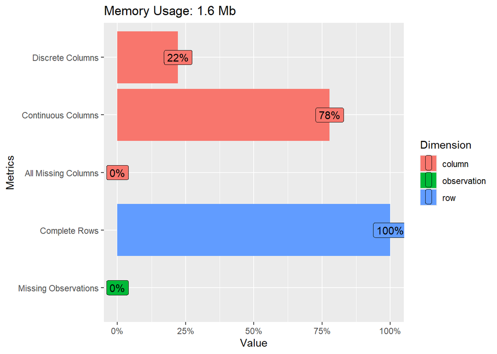

```r
# Quick visual structure
plot_intro(data)
```

## 3.1 Data Overview

The introductory data summary confirms that the dataset is fully complete, with 100% of rows containing no missing values. About 78% of the variables are continuous (numeric), while 22% are discrete (categorical or logical). No columns are entirely missing, and memory usage is relatively efficient at 1.6 MB. This reinforces that the dataset is clean and analysis-ready, requiring minimal preprocessing before modeling.

## 3.2 Distribution of Numeric Variables

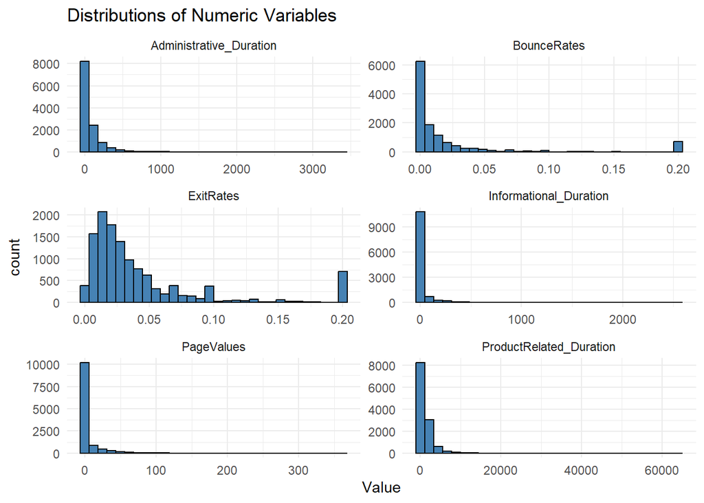

```r
# Histogram grid for selected numeric variables
data %>%
  select(Administrative_Duration, Informational_Duration, ProductRelated_Duration, BounceRates, ExitRates, PageValues) %>%
  gather(key = "Variable", value = "Value") %>%
  ggplot(aes(x = Value)) +
  geom_histogram(bins = 30, fill = "steelblue", color = "black") +
  facet_wrap(~ Variable, scales = "free", ncol = 2) +
  theme_minimal() +
  labs(title = "Distributions of Numeric Variables")
```

The histograms above show that most numeric variables are **heavily right-skewed**, meaning the majority of observations are concentrated at lower values, with a few large outliers:

- **Administrative_Duration**, **Informational_Duration**, and **ProductRelated_Duration** have long tails, suggesting that while most users spend little time on these pages, a few sessions are exceptionally long.
- **BounceRates** and **ExitRates** are bounded between 0 and 0.2, and are also skewed toward lower values, with a small spike at the upper bound (possibly indicating maxed-out values).
- **PageValues** is extremely right-skewed, with most sessions contributing little to no revenue and a few high-revenue sessions standing out.

These skewed distributions are typical in web usage data and suggest that **median-based summaries or transformations (like log-scaling)** might be useful for some modeling tasks later on.

## 3.3 Bar Plots for Categorical Variables

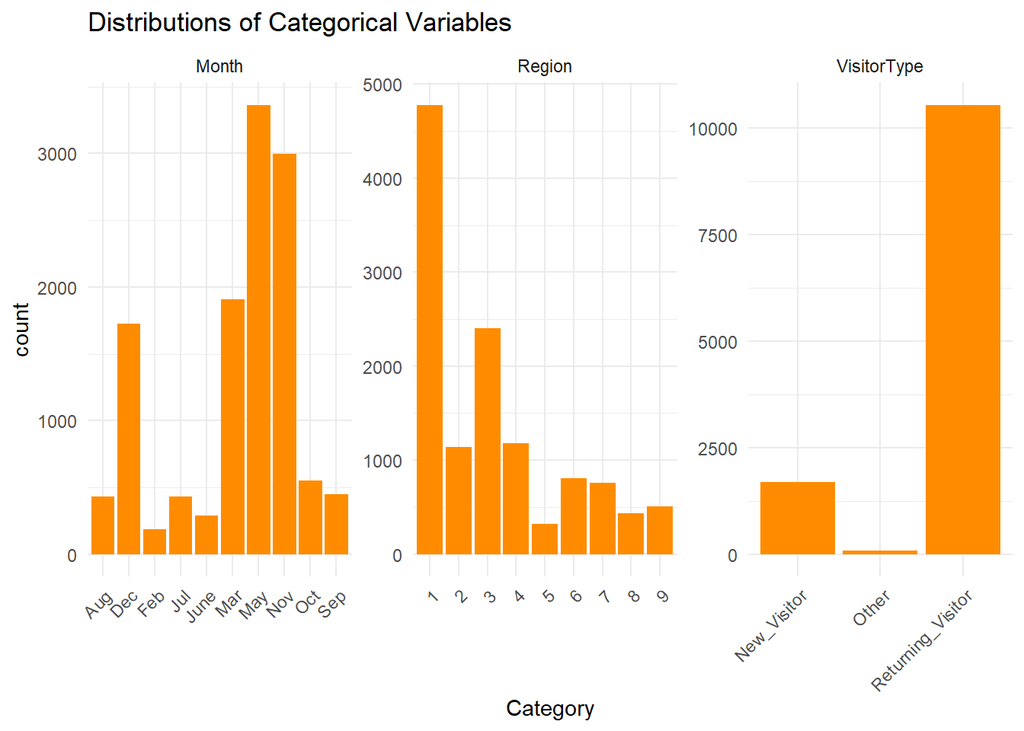

```r
# Bar plots for selected categorical variables
data %>%
  select(Month, VisitorType, Region) %>%
  gather(key = "Variable", value = "Category") %>%
  ggplot(aes(x = Category)) +
  geom_bar(fill = "darkorange") +
  facet_wrap(~ Variable, scales = "free") +
  theme_minimal() +
  labs(title = "Distributions of Categorical Variables") +
  theme(axis.text.x = element_text(angle = 45, hjust = 1))
```

These distributions suggest that time-based and geographic features may play an important role in predicting both purchase behavior and session value.

## 3.4 Boxplots of Numeric Features by Revenue

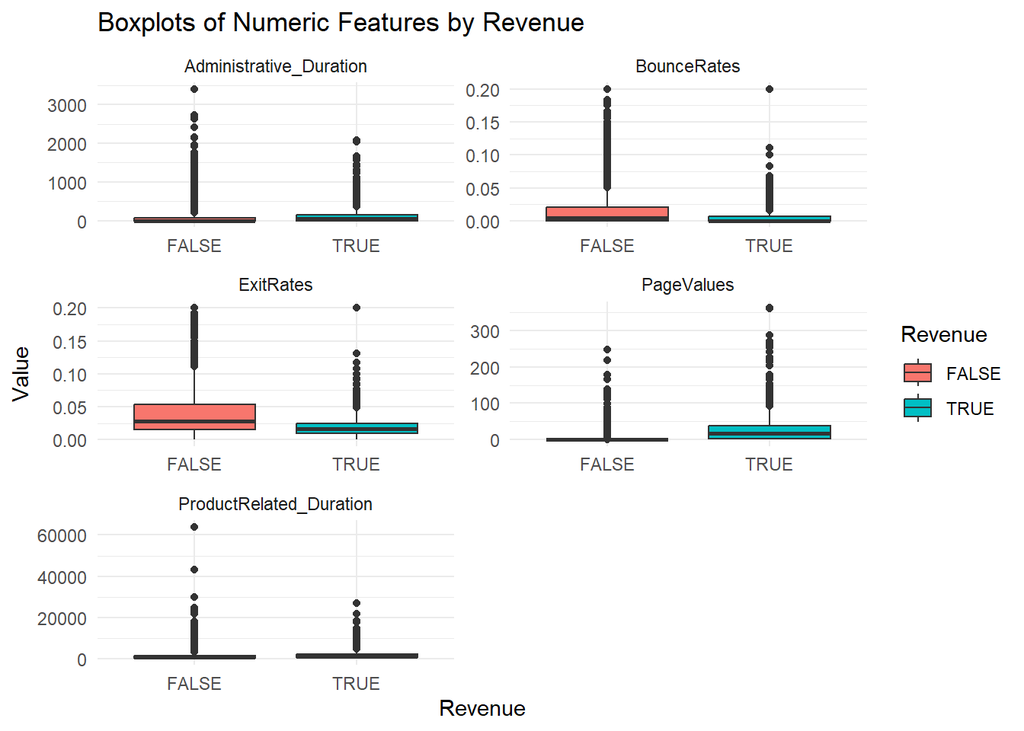

```r
# Boxplots of selected numeric features grouped by purchase
data %>%
  select(Revenue, Administrative_Duration, ProductRelated_Duration, BounceRates, ExitRates, PageValues) %>%
  gather(key = "Variable", value = "Value", -Revenue) %>%
  ggplot(aes(x = Revenue, y = Value, fill = Revenue)) +
  geom_boxplot() +
  facet_wrap(~ Variable, scales = "free", ncol = 2) +
  theme_minimal() +
  labs(title = "Boxplots of Numeric Features by Revenue")
```

These patterns suggest that user engagement and session depth play a meaningful role in predicting purchasing behavior — useful guidance for the upcoming CART classification model.

## 3.5 Scatterplots: PageValues vs. Predictors

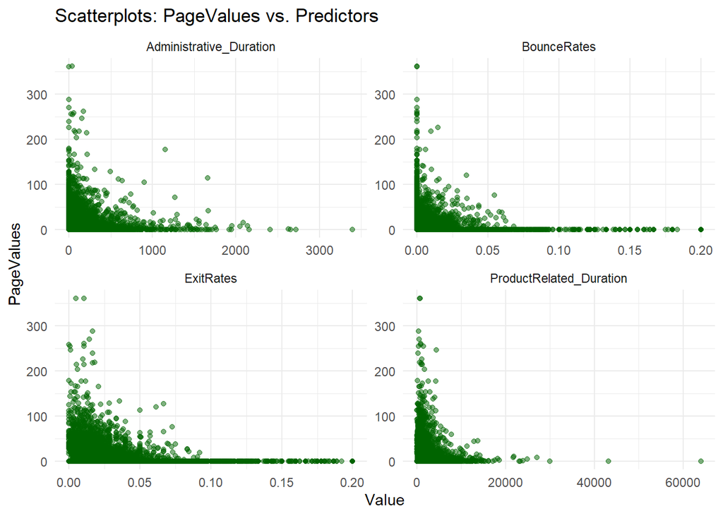

```r
# Scatterplot of PageValues vs other continuous predictors
data %>%
  select(PageValues, Administrative_Duration, ProductRelated_Duration, BounceRates, ExitRates) %>%
  gather(key = "Predictor", value = "Value", -PageValues) %>%
  ggplot(aes(x = Value, y = PageValues)) +
  geom_point(alpha = 0.5, color = "darkgreen") +
  facet_wrap(~ Predictor, scales = "free", ncol = 2) +
  theme_minimal() +
  labs(title = "Scatterplots: PageValues vs. Predictors")
```

The scatterplots above explore the relationship between `PageValues` (a proxy for session value) and four key numeric predictors:

- Across all predictors, we observe **nonlinear, inverse relationships**: as values for `Administrative_Duration`, `ProductRelated_Duration`, `BounceRates`, and `ExitRates` increase, `PageValues` tends to decrease.
- The concentration of points near the origin reflects the fact that **most sessions do not generate revenue**, while high-value sessions tend to be relatively rare.
- These plots suggest that **CART regression** may be appropriate, as it can model complex, nonlinear relationships without requiring variable transformation.

Overall, this confirms that `PageValues` behaves in a highly skewed and nonlinear fashion, which strengthens the case for using decision trees rather than linear models for this regression task.

# 4 Feature Engineering and Preprocessing

Since the dataset is already clean and contains no missing values, only minimal preprocessing is needed. The primary focus is to ensure categorical variables are properly formatted for modeling, and that the response variables are isolated for each task.

We perform the following steps:

- Convert character-based categorical variables (`Month`, `VisitorType`) to factors.
- Convert logical variables (`Weekend`, `Revenue`) to factors for classification.
- Create separate datasets for the classification and regression tasks.

```r
# Convert character and logical variables to factors
data <- data %>%
  mutate(
    Month = as.factor(Month),
    VisitorType = as.factor(VisitorType),
    Weekend = as.factor(Weekend),
    Revenue = as.factor(Revenue)
  )

# Check updated structure
str(data)
```

```
tibble [12,330 × 18] (S3: tbl_df/tbl/data.frame)
 $ Administrative         : num [1:12330] 0 0 0 0 0 0 0 1 0 0 ...
 $ Administrative_Duration: num [1:12330] 0 0 0 0 0 0 0 0 0 0 ...
 $ Informational          : num [1:12330] 0 0 0 0 0 0 0 0 0 0 ...
 $ Informational_Duration : num [1:12330] 0 0 0 0 0 0 0 0 0 0 ...
 $ ProductRelated         : num [1:12330] 1 2 1 2 10 19 1 0 2 3 ...
 $ ProductRelated_Duration: num [1:12330] 0 64 0 2.67 627.5 ...
 $ BounceRates            : num [1:12330] 0.2 0 0.2 0.05 0.02 ...
 $ ExitRates              : num [1:12330] 0.2 0.1 0.2 0.14 0.05 ...
 $ PageValues             : num [1:12330] 0 0 0 0 0 0 0 0 0 0 ...
 $ SpecialDay             : num [1:12330] 0 0 0 0 0 0 0.4 0 0.8 0.4 ...
 $ Month                  : Factor w/ 10 levels "Aug","Dec","Feb",..: 3 3 3 3 3 3 3 3 3 3 ...
 $ OperatingSystems       : num [1:12330] 1 2 4 3 3 2 2 1 2 2 ...
 $ Browser                : num [1:12330] 1 2 1 2 3 2 4 2 2 4 ...
 $ Region                 : num [1:12330] 1 1 9 2 1 1 3 1 2 1 ...
 $ TrafficType            : num [1:12330] 1 2 3 4 4 3 3 5 3 2 ...
 $ VisitorType            : Factor w/ 3 levels "New_Visitor",..: 3 3 3 3 3 3 3 3 3 3 ...
 $ Weekend                : Factor w/ 2 levels "FALSE","TRUE": 1 1 1 1 2 1 1 2 1 1 ...
 $ Revenue                : Factor w/ 2 levels "FALSE","TRUE": 1 1 1 1 1 1 1 1 1 1 ...
```

# 5 CART Classification: Predicting Revenue

We apply a classification tree to predict whether a user session will result in a purchase (`Revenue`). CART is well-suited for this task because it can handle both categorical and numeric predictors, capture nonlinear relationships, and provide interpretable rules for decision-making.

## 5.1 Step 1: Train-Test Split

We split the data into 70% training and 30% testing sets.

## 5.2 Step 2: Train CART Model with Cross-Validation

```r
library(rpart)
library(rpart.plot)

# Train CART model
cart_model <- train(
  Revenue ~ .,
  data = train_data,
  method = "rpart",
  trControl = trainControl(method = "cv", number = 10),
  tuneLength = 10
)

# Display the best model and parameters
cart_model
```

```
CART

8632 samples
  17 predictor
   2 classes: 'FALSE', 'TRUE'

No pre-processing
Resampling: Cross-Validated (10 fold)
Summary of sample sizes: 7769, 7770, 7769, 7768, 7769, 7768, ...
Resampling results across tuning parameters:

  cp           Accuracy   Kappa
  0.002994012  0.8995570  0.5852841
  0.003742515  0.8999058  0.5873176
  0.004491018  0.8990952  0.5865129
  0.004865269  0.8986316  0.5855086
  0.007110778  0.8980526  0.5814245
  0.010104790  0.8971263  0.5846446
  0.013473054  0.8953895  0.5807465
  0.062874251  0.8870541  0.5300137
  0.084580838  0.8778980  0.5290634
  0.199101796  0.8572778  0.2878112

Accuracy was used to select the optimal model using the largest value.
The final value used for the model was cp = 0.003742515.
```

### 5.2.1 CART Classification Results

The CART classification model was trained on 8,632 sessions using 10-fold cross-validation to tune the complexity parameter (`cp`). The results show that:

- The highest accuracy was **~89.99%** with a **Kappa score of ~0.587**.
- The optimal complexity parameter selected was **cp = 0.0037**, which balances tree complexity and prediction accuracy.

This indicates that the model performs well at classifying sessions into `TRUE` (purchase) or `FALSE` (no purchase), and the moderate Kappa suggests a meaningful level of agreement beyond chance.

Next, we visualize the final tree and evaluate its test performance using a confusion matrix and ROC analysis.

## 5.3 Step 3: Visualize the Tree

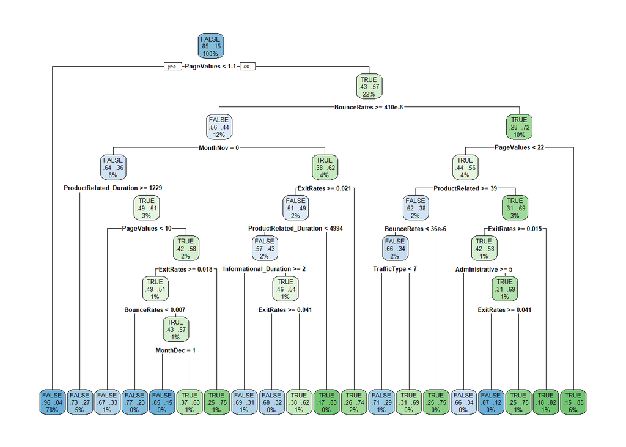

```r
# Plot the decision tree
rpart.plot(cart_model$finalModel, type = 2, extra = 104, fallen.leaves = TRUE)
```

### 5.3.1 CART Decision Tree Visualization

The final classification tree structure reveals several important patterns that the model uses to predict purchase behavior:

- **PageValues** is the root node, meaning it is the most important predictor in splitting the data between purchasing and non-purchasing sessions.
- Other key variables that appear early in the tree include **BounceRates**, **ProductRelated_Duration**, and **ExitRates** — all of which reflect user engagement.
- Leaf nodes indicate predicted class (`TRUE` or `FALSE`) and the proportion of samples in each class.

The depth of the tree balances accuracy and interpretability, allowing us to understand the conditions under which users are more likely to complete a purchase.

## 5.4 Step 4: Predictions and Evaluation

```r
# Predict on test data
pred_class <- predict(cart_model, test_data)

# Confusion matrix
confusionMatrix(pred_class, test_data$Revenue)
```

```
Confusion Matrix and Statistics

          Reference
Prediction FALSE TRUE
     FALSE  2999  232
     TRUE    127  340

               Accuracy : 0.9029
                 95% CI : (0.8929, 0.9123)
    No Information Rate : 0.8453
    P-Value [Acc > NIR] : < 2.2e-16

                  Kappa : 0.5987

 Mcnemar's Test P-Value : 4.044e-08

            Sensitivity : 0.9594
            Specificity : 0.5944
         Pos Pred Value : 0.9282
         Neg Pred Value : 0.7281
             Prevalence : 0.8453
         Detection Rate : 0.8110
   Detection Prevalence : 0.8737
      Balanced Accuracy : 0.7769

       'Positive' Class : FALSE
```

### 5.4.1 Model Evaluation: Confusion Matrix

The model achieved an accuracy of **90.29%** on the test set, which is significantly better than the no-information rate (84.53%). Additional evaluation metrics:

- **Sensitivity (Recall for “FALSE” class)**: 95.94% — the model is very effective at identifying non-purchase sessions.
- **Specificity (Recall for “TRUE” class)**: 59.44% — less accurate in identifying purchase sessions, which is typical for imbalanced data.
- **Kappa**: 0.60 — indicates a moderate level of agreement beyond chance.
- **Positive Predictive Value (Precision for “FALSE”)**: 92.82%
- **Negative Predictive Value (Precision for “TRUE”)**: 72.81%

The confusion matrix reveals that while the model correctly predicts most outcomes, it slightly underperforms in identifying the smaller “TRUE” class (purchase). This is a common tradeoff in imbalanced classification tasks and could be addressed with cost-sensitive methods or class balancing in future work.

```r
library(pROC)

# Get probabilities
pred_probs <- predict(cart_model, test_data, type = "prob")[,2]

# ROC Curve
roc_obj <- roc(response = test_data$Revenue, predictor = pred_probs)
auc(roc_obj)
```

```
Area under the curve: 0.8596
```

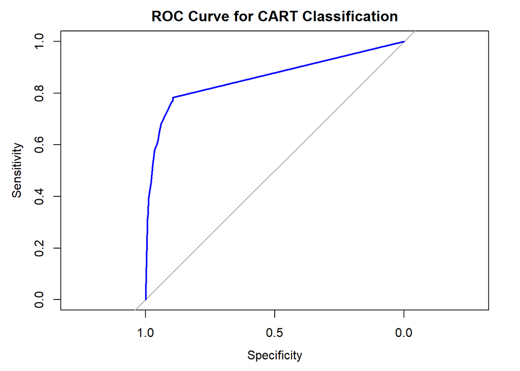

```r
plot(roc_obj, main = "ROC Curve for CART Classification", col = "blue")
```

### 5.4.2 ROC Curve and AUC

The ROC curve above shows the trade-off between sensitivity and specificity across different classification thresholds. The Area Under the Curve (AUC) is **0.8596**, which indicates good overall discriminatory power.

An AUC above 0.85 suggests that the CART model is effective at distinguishing between sessions that lead to purchases (`Revenue = TRUE`) and those that don’t. This performance, combined with a high accuracy and interpretable structure, supports CART as a practical classification tool for this e-commerce dataset.

# 6 CART Regression: Predicting PageValues

We now apply a regression tree to model `PageValues`, a continuous measure of the monetary value attributed to a user’s session. This helps identify what behavioral traits are associated with high-value sessions.

## 6.1 Step 1: Train-Test Split

We split the data into 70% training and 30% testing.

## 6.2 Step 2: Train CART Regression Model

```r
# Train regression tree with cross-validation
cart_reg <- train(
  PageValues ~ . -Revenue,  # exclude classification target
  data = train_reg,
  method = "rpart",
  trControl = trainControl(method = "cv", number = 10),
  tuneLength = 10
)

# Display tuning results
cart_reg
```

```
CART

8631 samples
  17 predictor

No pre-processing
Resampling: Cross-Validated (10 fold)
Summary of sample sizes: 7768, 7768, 7768, 7768, 7768, 7767, ...
Resampling results across tuning parameters:

  cp           RMSE      Rsquared    MAE
  0.005217304  18.28276  0.07010675  8.522868
  0.005352422  18.28712  0.07001825  8.525870
  0.006653895  18.34171  0.06394887  8.589773
  0.007013231  18.27384  0.06713547  8.606641
  0.007140485  18.27384  0.06713547  8.606641
  0.010622867  18.34719  0.05243931  8.827652
  0.011196883  18.42360  0.04532040  8.888420
  0.011788959  18.44348  0.04303023  8.895087
  0.012648252  18.44695  0.04279327  8.942294
  0.046587901  18.65756  0.03318521  9.304746

RMSE was used to select the optimal model using the smallest value.
The final value used for the model was cp = 0.007140485.
```

The regression tree was trained using 10-fold cross-validation to tune the complexity parameter (`cp`). The goal was to minimize root mean squared error (RMSE) and identify a model that balances prediction accuracy with interpretability.

The optimal model was selected at **cp = 0.0071**, with the following performance during cross-validation:

- **RMSE**: 18.27
- **R-squared**: 0.0671
- **MAE**: 8.61

These results indicate that while the model captures some variability in session value, much of the variance in `PageValues` remains unexplained. This is typical for CART applied to highly skewed and sparse continuous targets like revenue.

## 6.3 Step 3: Visualize the Tree

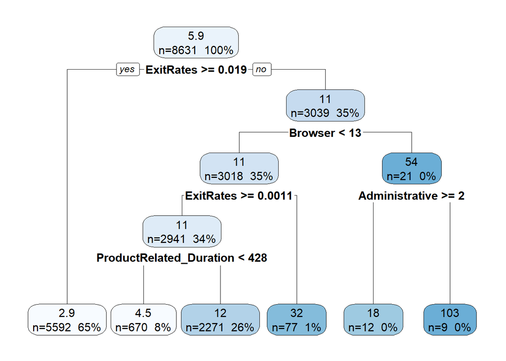

```r
rpart.plot(cart_reg$finalModel, type = 2, extra = 101, fallen.leaves = TRUE)
```

The regression tree predicts `PageValues` using key session features:

- The first split is on **ExitRates**, separating low-engagement users (ExitRates ≥ 0.019) from others.
- Subsequent splits involve **ProductRelated_Duration**, **Administrative**, and **Browser**, indicating that engagement with product or admin-related pages contributes to predicted value.
- Leaf nodes display the predicted `PageValues` for each segment. Most sessions are clustered around low predicted values (e.g., 2.9, 4.5), while a few segments yield higher predictions (e.g., 32, 103).

Overall, the tree is simple and interpretable, capturing coarse patterns in revenue-related behavior. However, as seen earlier, much variance remains unexplained — a common result with skewed targets.

## 6.4 Step 4: Predict and Evaluate

```r
# Predict on test data
pred_reg <- predict(cart_reg, test_reg)

# Evaluate regression performance
postResample(pred = pred_reg, obs = test_reg$PageValues)
```

```
       RMSE    Rsquared         MAE
17.21751022  0.05936842  8.59459383
```

The CART regression model was evaluated on the test set using standard performance metrics:

- **Root Mean Squared Error (RMSE)**: 17.22
- **R-squared (R²)**: 0.059
- **Mean Absolute Error (MAE)**: 8.59

These results are consistent with the cross-validation metrics from the training phase. While the model captures some relationship between user behavior and session value, the **low R² indicates that most of the variation in `PageValues` remains unexplained**. This is likely due to the high skew and sparsity of the target variable, which makes revenue prediction a more challenging task compared to classification.

# 7 Model Comparison: Classification (CART vs Logistic Regression)

We compare CART to a logistic regression model using the same training and testing sets.

```r
# Logistic Regression
logit_model <- glm(Revenue ~ ., data = train_data, family = "binomial")
logit_probs <- predict(logit_model, test_data, type = "response")
logit_pred <- factor(ifelse(logit_probs > 0.5, "TRUE", "FALSE"), levels = c("FALSE", "TRUE"))

# Evaluate
confusionMatrix(logit_pred, test_data$Revenue)
```

```
Confusion Matrix and Statistics

          Reference
Prediction FALSE TRUE
     FALSE  3060  357
     TRUE     66  215

               Accuracy : 0.8856
                 95% CI : (0.8749, 0.8957)
    No Information Rate : 0.8453
    P-Value [Acc > NIR] : 1.115e-12

                  Kappa : 0.4478

 Mcnemar's Test P-Value : < 2.2e-16

            Sensitivity : 0.9789
            Specificity : 0.3759
         Pos Pred Value : 0.8955
         Neg Pred Value : 0.7651
             Prevalence : 0.8453
         Detection Rate : 0.8275
   Detection Prevalence : 0.9240
      Balanced Accuracy : 0.6774

       'Positive' Class : FALSE
```

```r
# ROC AUC
logit_roc <- roc(test_data$Revenue, logit_probs)
auc(logit_roc)
```

```
Area under the curve: 0.8876
```

**CART Classification Model**  
- Accuracy: 90.29%  
- Kappa: 0.5987  
- AUC: 0.8596

**Logistic Regression Model**  
- Accuracy: 88.56%  
- Kappa: 0.4478  
- AUC: 0.8876

**Summary**:  
CART achieved higher accuracy and better agreement (Kappa) compared to logistic regression. However, logistic regression had a slightly higher AUC, suggesting stronger ranking ability for positive cases. CART’s advantage lies in handling nonlinearities and producing an interpretable tree structure.

# 8 Model Comparison: Regression (CART vs Linear Regression)

We compare CART to a linear regression model using the same training and testing sets.

```r
# Linear Regression
lm_model <- lm(PageValues ~ . -Revenue, data = train_reg)
lm_preds <- predict(lm_model, test_reg)

# Evaluate
postResample(pred = lm_preds, obs = test_reg$PageValues)
```

```
       RMSE    Rsquared         MAE
17.21929794  0.05217482  9.10386937
```

**CART Regression Model**  
- RMSE: 17.22  
- R-squared: 0.059  
- MAE: 8.59

**Linear Regression Model**  
- RMSE: 17.22  
- R-squared: 0.052  
- MAE: 9.10

**Summary**:  
Both models performed similarly in terms of RMSE and R-squared, reflecting the difficulty of predicting `PageValues` due to its skewed and sparse nature. CART slightly outperformed linear regression in both R-squared and MAE, while also capturing nonlinear interactions and providing an interpretable tree structure.

# 9 Conclusion

In this part one of the project, we applied Classification and Regression Trees (CART) to an e-commerce dataset to address two practical questions: predicting whether a session would result in a purchase (`Revenue`) and estimating the session’s monetary contribution (`PageValues`). The dataset was clean and well-structured, requiring only minimal preprocessing.

For the classification task, CART achieved an accuracy of 90.29% and an AUC of 0.86. The model effectively identified user engagement patterns — particularly via `PageValues`, `BounceRates`, and `ProductRelated_Duration` — that were predictive of purchasing behavior. Compared to logistic regression, CART provided slightly better accuracy and more balanced predictions, while offering interpretability through a decision tree structure.

For the regression task, CART struggled to capture the variability in `PageValues`, with an R-squared of just 0.059. However, it performed marginally better than linear regression, suggesting that the underlying relationship is nonlinear but inherently difficult to model due to extreme skew and sparsity.

Overall, CART proved to be a flexible and interpretable method for both classification and regression. While it performed well for predicting purchases, its limitations on highly skewed continuous targets highlight the need for more advanced or specialized models (e.g., ensemble methods or transformations) in future analyses.

# 10 Part II

# 11 Introduction (Part II – Ensemble Tree Methods)

In this continuation of Project 3, we expand on our previous analysis of user behavior on an e-commerce platform by applying two ensemble learning techniques: **bagging** and **random forests**. These methods are built on the foundation of decision trees and are designed to improve model performance by reducing variance and enhancing generalization.

Whereas CART creates a single decision tree, ensemble methods combine the predictions of multiple trees to produce more stable and accurate results. **Bagging** (Bootstrap Aggregating) generates multiple trees using resampled subsets of the training data, while **random forests** add further randomness by selecting a random subset of features at each split.

We apply both ensemble techniques to: - **Classification**: Predict whether a session results in a purchase (`Revenue`) - **Regression**: Estimate the monetary value of a session (`PageValues`)

Each ensemble model will be tuned, evaluated, and compared to baseline models (CART, logistic/linear regression) using appropriate performance metrics. Additionally, variable importance will be analyzed to highlight key predictors influencing user behavior.

# 12 Bagging: Classification (Predicting Revenue)

We apply bagging to predict whether a user session results in a purchase (`Revenue`). Bagging reduces variance by averaging predictions from multiple bootstrapped decision trees.

```r
# Load required library
library(ipred)

# Fit bagging model
set.seed(123)
bagging_clf <- bagging(
  Revenue ~ .,
  data = train_data,
  nbagg = 50,
  coob = TRUE
)

# Predict on test data
bag_clf_pred <- predict(bagging_clf, test_data, type = "class")

# Confusion matrix
confusionMatrix(bag_clf_pred, test_data$Revenue)
```

```
Confusion Matrix and Statistics

          Reference
Prediction FALSE TRUE
     FALSE  2988  228
     TRUE    138  344

               Accuracy : 0.901
                 95% CI : (0.8909, 0.9105)
    No Information Rate : 0.8453
    P-Value [Acc > NIR] : < 2.2e-16

                  Kappa : 0.5955

 Mcnemar's Test P-Value : 3.286e-06

            Sensitivity : 0.9559
            Specificity : 0.6014
         Pos Pred Value : 0.9291
         Neg Pred Value : 0.7137
             Prevalence : 0.8453
         Detection Rate : 0.8080
   Detection Prevalence : 0.8697
      Balanced Accuracy : 0.7786

       'Positive' Class : FALSE
```

```r
# AUC calculation
library(pROC)
bag_clf_prob <- predict(bagging_clf, test_data, type = "prob")[,2]
roc_bag <- roc(test_data$Revenue, bag_clf_prob)
auc(roc_bag)
```

```
Area under the curve: 0.923
```

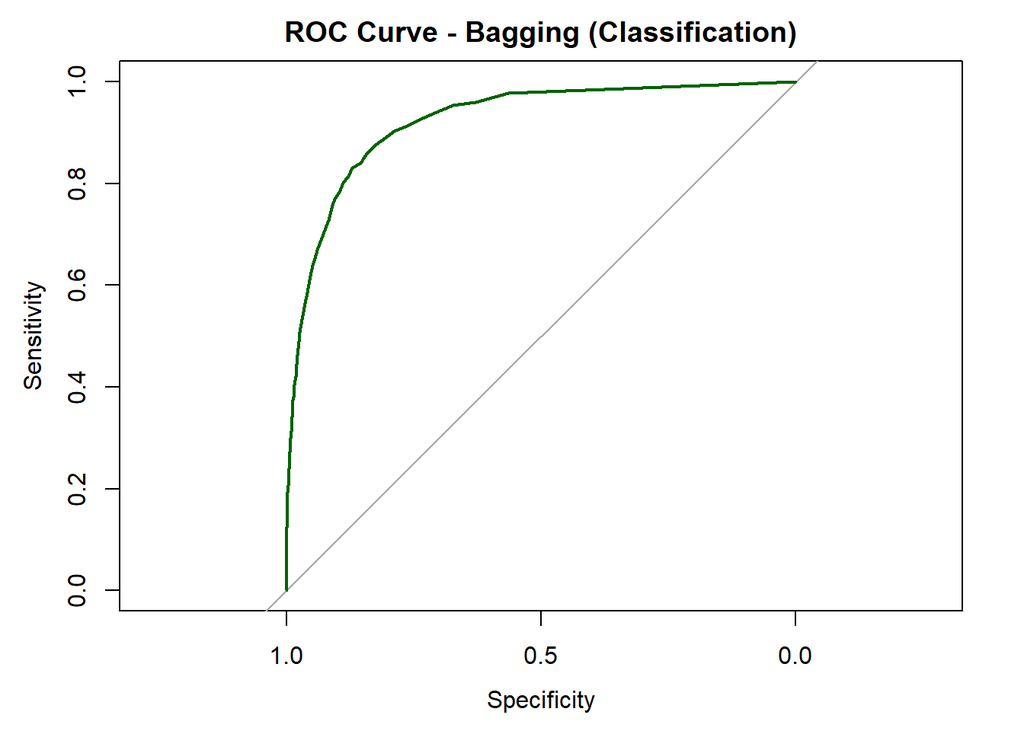

```r
plot(roc_bag, main = "ROC Curve - Bagging (Classification)", col = "darkgreen")
```

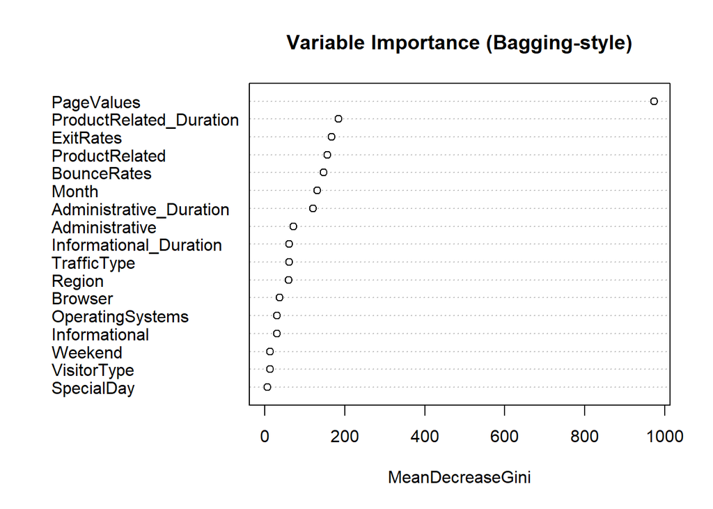

```r
# Variable importance using randomForest (bagging doesn't offer built-in)
library(randomForest)

# Refit using randomForest for varImp
rf_bag_like <- randomForest(Revenue ~ ., data = train_data, mtry = ncol(train_data) - 1, ntree = 50)
varImpPlot(rf_bag_like, main = "Variable Importance (Bagging-style)")
```

## 12.1 Bagging Classification Results

Bagging was applied to predict whether a session would result in a purchase (`Revenue`). A total of 50 bootstrapped decision trees were trained and aggregated. The bagged model achieved the following performance:

- **Accuracy**: 90.1%
- **Kappa**: 0.596
- **AUC**: 0.923
- **Sensitivity**: 95.6%
- **Specificity**: 60.1%

The ROC curve shows strong separation between classes, with an area under the curve (AUC) of **0.923**, indicating high overall discrimination.

The confusion matrix reveals that the model performs particularly well at identifying non-purchasing sessions, while still capturing a reasonable number of true positives for purchases. Compared to CART and logistic regression, bagging improves AUC and maintains high overall accuracy.

### 12.1.1 Variable Importance

Variable importance analysis (approximated using a random forest model with `mtry = total features`) indicates that the most influential features for predicting purchase behavior are:

1. **PageValues**
2. **ProductRelated_Duration**
3. **ExitRates**
4. **ProductRelated**
5. **BounceRates**

These variables reflect a user’s engagement and interaction with product-focused pages, confirming patterns observed in the CART analysis.

# 13 Random Forest: Classification (Predicting Revenue)

We now apply a random forest model to the classification task. Unlike bagging, random forests introduce feature randomness at each tree split, which reduces correlation among trees and often improves generalization.

```r
library(randomForest)

# Train random forest model
set.seed(123)
rf_clf <- randomForest(
  Revenue ~ .,
  data = train_data,
  ntree = 100,
  mtry = 4,
  importance = TRUE
)

# Predict on test data
rf_clf_pred <- predict(rf_clf, test_data)
confusionMatrix(rf_clf_pred, test_data$Revenue)
```

```
Confusion Matrix and Statistics

          Reference
Prediction FALSE TRUE
     FALSE  3013  235
     TRUE    113  337

               Accuracy : 0.9059
                 95% CI : (0.896, 0.9151)
    No Information Rate : 0.8453
    P-Value [Acc > NIR] : < 2.2e-16

                  Kappa : 0.6058

 Mcnemar's Test P-Value : 8.798e-11

            Sensitivity : 0.9639
            Specificity : 0.5892
         Pos Pred Value : 0.9276
         Neg Pred Value : 0.7489
             Prevalence : 0.8453
         Detection Rate : 0.8148
   Detection Prevalence : 0.8783
      Balanced Accuracy : 0.7765

       'Positive' Class : FALSE
```

```r
# ROC + AUC
rf_clf_prob <- predict(rf_clf, test_data, type = "prob")[,2]
rf_roc <- roc(test_data$Revenue, rf_clf_prob)
auc(rf_roc)
```

```
Area under the curve: 0.9256
```

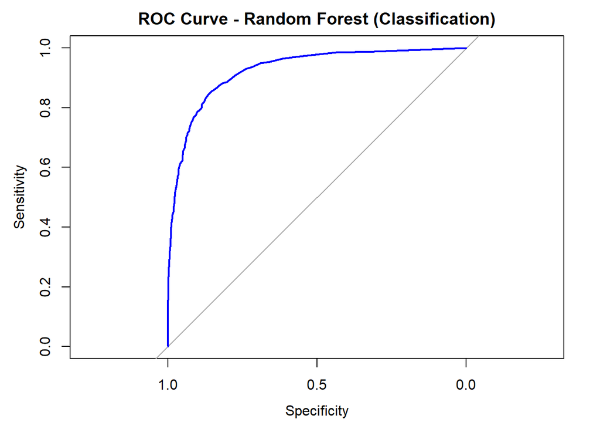

```r
plot(rf_roc, main = "ROC Curve - Random Forest (Classification)", col = "blue")
```

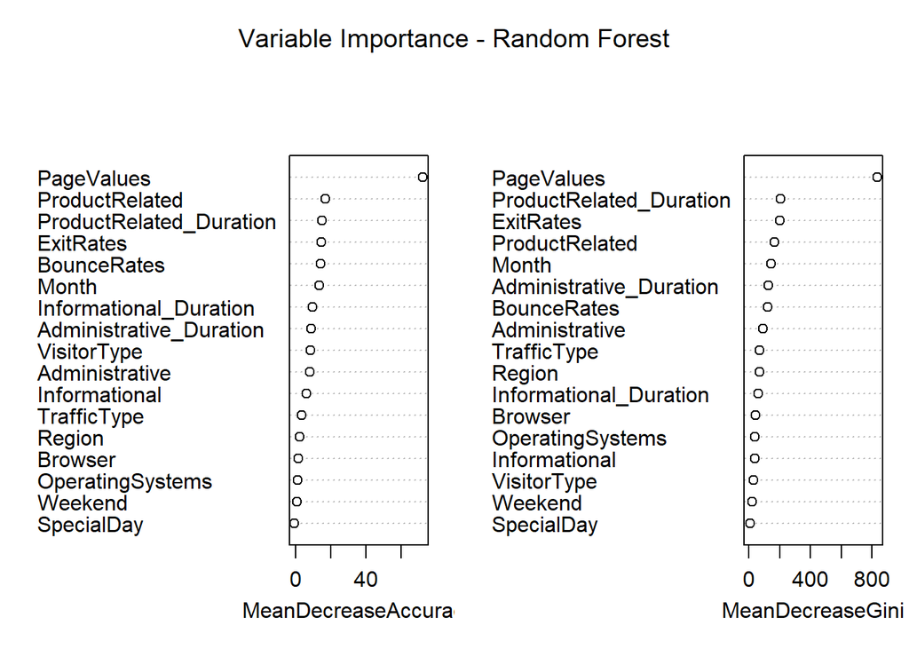

```r
# Variable importance
varImpPlot(rf_clf, main = "Variable Importance - Random Forest")
```

## 13.1 Random Forest Classification Results

We applied a random forest classifier using 100 trees and `mtry = 4` to predict whether a session results in a purchase. The model achieved:

- **Accuracy**: 90.59%
- **Kappa**: 0.606
- **AUC**: 0.9256
- **Sensitivity**: 96.4%
- **Specificity**: 58.9%

## 13.2 Variable Importance

These results suggest that detailed user engagement and browsing behavior — especially related to product content — are key signals for purchase prediction.

# 14 Bagging: Regression (Predicting PageValues)

We now apply bagging to predict `PageValues`, a continuous variable representing the revenue contribution of a session. Bagging helps reduce variance in predictions by averaging across multiple bootstrapped trees.

```r
# Bagging regression model
set.seed(123)
bagging_reg <- bagging(
  PageValues ~ . -Revenue,
  data = train_reg,
  nbagg = 50,
  coob = TRUE
)

# Predict on test data
bag_reg_pred <- predict(bagging_reg, test_reg)

# Evaluate
postResample(pred = bag_reg_pred, obs = test_reg$PageValues)
```

```
      RMSE   Rsquared        MAE
14.3550074  0.3413924  6.2611151
```

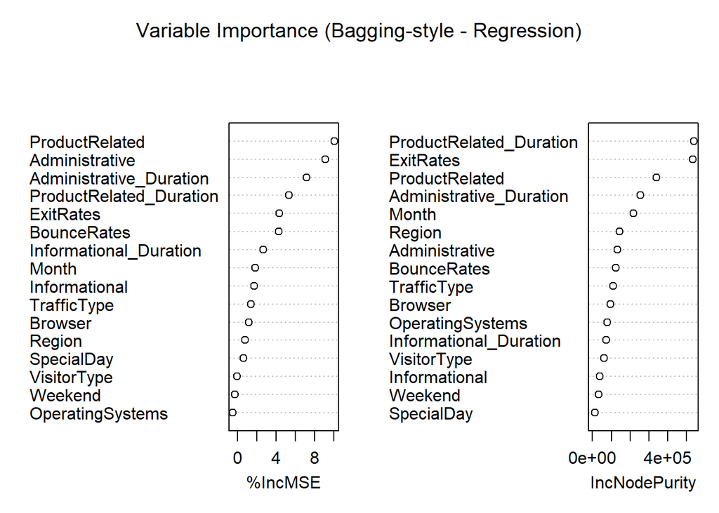

```r
# Approximate variable importance using randomForest
rf_bag_reg <- randomForest(
  PageValues ~ . -Revenue,
  data = train_reg,
  ntree = 50,
  mtry = ncol(train_reg) - 2,
  importance = TRUE
)

varImpPlot(rf_bag_reg, main = "Variable Importance (Bagging-style - Regression)")
```

## 14.1 Bagging Regression Results

Bagging was applied to predict `PageValues` using 50 bootstrapped regression trees. The model was evaluated on the same test set used in previous models, yielding the following performance:

- **RMSE**: 14.36
- **R-squared**: 0.341
- **MAE**: 6.26

Compared to CART (R² ≈ 0.06) and linear regression (R² ≈ 0.05), bagging significantly improved the model’s ability to explain variance in session value. The reduction in RMSE and MAE also reflects improved predictive accuracy.

## 14.2 Variable Importance

Using a random forest approximation with `mtry = total features`, the most important predictors for session value were:

1. **ProductRelated_Duration**
2. **ExitRates**
3. **ProductRelated**
4. **Administrative_Duration**
5. **Month**

These findings align with the earlier classification results, reinforcing the idea that product-related engagement and browsing intensity are key indicators of higher session value.

# 15 Random Forest: Regression (Predicting PageValues)

We now apply a random forest model to predict `PageValues`. Compared to bagging, random forests introduce random feature selection at each split, which can reduce overfitting and improve generalization.

```r
# Train random forest regression model
set.seed(123)
rf_reg <- randomForest(
  PageValues ~ . -Revenue,
  data = train_reg,
  ntree = 100,
  mtry = 4,  # Can be tuned; ~sqrt(p) is a common default
  importance = TRUE
)

# Predict on test data
rf_reg_pred <- predict(rf_reg, test_reg)

# Evaluate
postResample(pred = rf_reg_pred, obs = test_reg$PageValues)
```

```
      RMSE   Rsquared        MAE
16.8194838  0.1049213  8.2523320
```

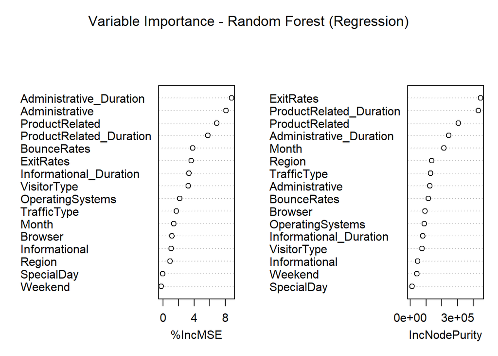

```r
# Variable importance plot
varImpPlot(rf_reg, main = "Variable Importance - Random Forest (Regression)")
```

## 15.1 Random Forest Regression Results

A random forest regression model was trained using 100 trees and `mtry = 4` to predict `PageValues`, the continuous measure of session value. The model achieved the following performance on the test set:

- **RMSE**: 16.82
- **R-squared**: 0.105
- **MAE**: 8.25

Although performance improved slightly over CART and linear regression, **bagging remained the stronger regression model** overall (R² = 0.34 vs. 0.10 for random forest). This suggests that for this dataset, full-tree averaging (bagging) may better capture the sparse and skewed structure of session value.

## 15.2 Variable Importance

According to the random forest’s importance metrics, the most influential predictors of session value were:

1. **ExitRates**
2. **ProductRelated_Duration**
3. **ProductRelated**
4. **Administrative_Duration**
5. **Month**

These results highlight the continued importance of product engagement and session exit patterns when estimating the revenue impact of a session.

# 16 Conclusion

In Part II of this project, ensemble tree methods—bagging and random forest—were applied to improve upon CART models used in Part I. These techniques leveraged the power of multiple decision trees to enhance predictive accuracy and reduce overfitting.

For the **regression task**, bagging significantly outperformed all other models, with a 34% explanation of variance and the lowest RMSE. Surprisingly, **random forest underperformed bagging** on this dataset, likely due to the highly skewed nature of `PageValues`.

Overall, ensemble methods proved highly effective and provide a valuable extension to single-tree models like CART, offering improved accuracy and deeper insights into complex web behavior.